# TO404HW1_Final

Danielle Bidigare, in partnership with Jeffrey Sondheimer

11/1/2020

```r
nyc<- read.csv("nycflights.csv")
```

```r
nyc$carrier <- as.factor(nyc$carrier)
nyc$flight <- as.factor(nyc$flight)
nyc$tailnum <- as.factor(nyc$tailnum)
nyc$origin <- as.factor(nyc$origin)
nyc$dest <- as.factor(nyc$dest)
```

## Data Exploration

### How many airlines are there?

```r
total_num_airlines <- length(levels(nyc$carrier))
total_num_airlines
```

```
## [1] 16
```

**There are 16 airlines**

### How many flights there were by the airline with code `OO`?

```r
airline_code_OO <- nrow(nyc[nyc$airline == "OO",])
airline_code_OO
```

```
## [1] 0
```

### How long is the shortest flight out of any NYC airport?

```r
shortest_flight <- min(nyc$air_time, na.rm=TRUE)
shortest_flight
```

```
## [1] 20
```

**The shortest flight out of any NYC airport is 20 minutes.**

### How many flights where there by United Airlines (code: UA) on Jan 12th 2013?

```r
jan_12_2013_UAFlights <- nrow(nyc[nyc$carrier=="UA" & nyc$year==2013 & nyc$month==1 & nyc$day==12,])
jan_12_2013_UAFlights
```

```
## [1] 112
```

**On January 12th, 2013, there were 112 United Airlines flights.**

## Arrival Delay

### What was the average arrival delay for all airports and all airlines combined in Jan 2013?

```r
average_arrival_delay_Jan2013 <- round(mean(nyc$arr_delay[nyc$year==2013 & nyc$month==1], na.rm=TRUE),2)
average_arrival_delay_Jan2013
```

```
## [1] 6.13
```

**The average arrival delay for all airports and all airlines combined in January 2013 is 6.13 minutes.**

### What was the median arrival delay for all airports and all airlines combined in Jan 2013?

```r
median_arrival_delay_Jan2013 <- median(nyc$arr_delay[nyc$year==2013 & nyc$month==1],na.rm=TRUE)
median_arrival_delay_Jan2013
```

```
## [1] -3
```

**The median arrival delay for all airports and all airlines combined in January 2013 was -3 minutes.**

## Airline Performance

### Average arrival delays by airline

```r
average_arr_delay_airline <- round(tapply(nyc$arr_delay, nyc$carrier, mean, na.rm=TRUE), 2)
average_arr_delay_airline
```

```
##    9E    AA    AS    B6    DL    EV    F9    FL    HA    MQ    OO    UA    US
##  7.38  0.36 -9.93  9.46  1.64 15.80 21.92 20.12 -6.92 10.77 11.93  3.56  2.13
##    VX    WN    YV
##  1.76  9.65 15.56
```

```r
sort(average_arr_delay_airline, decreasing = FALSE)
```

```
##    AS    HA    AA    DL    VX    US    UA    9E    B6    WN    MQ    OO    YV
## -9.93 -6.92  0.36  1.64  1.76  2.13  3.56  7.38  9.46  9.65 10.77 11.93 15.56
##    EV    FL    F9
## 15.80 20.12 21.92
```

Barplot of these average arrival delays by airline:

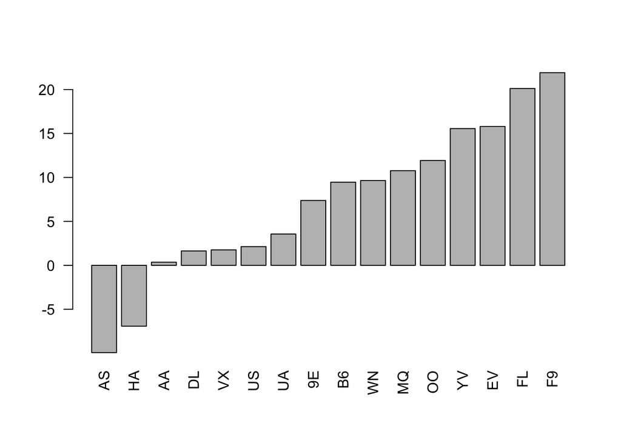

```r
barplot(sort(average_arr_delay_airline, decreasing = FALSE), las=2)
```

### Which airline has the highest average arrival delay? Which airline has the smallest average arrival delay? Are there airlines that actually have negative average delay?

```r
highest_avg_airline_delay <- names(average_arr_delay_airline[average_arr_delay_airline==max(average_arr_delay_airline)])
highest_avg_airline_delay
```

```
## [1] "F9"
```

```r
smallest_avg_airline_delay <- names(average_arr_delay_airline[average_arr_delay_airline==min(average_arr_delay_airline)])
smallest_avg_airline_delay
```

```
## [1] "AS"
```

```r
negative_avg_airline_delay <- names(average_arr_delay_airline[average_arr_delay_airline<0])
negative_avg_airline_delay
```

```
## [1] "AS" "HA"
```

**F9 has the highest average arrival delay, and AS has the smallest average arrival delay. AS, HA have negative average airlines delays.**

## Air Gain

The following is a histogram of airgain:

```r
nyc$airgain <- nyc$dep_delay-nyc$arr_delay
summary(nyc$airgain)
```

```
##    Min. 1st Qu.  Median    Mean 3rd Qu.    Max.    NA's
## -196.00   -3.00    7.00    5.66   17.00  109.00    9430
```

```r
mean(nyc$airgain, na.rm=TRUE)
```

```
## [1] 5.659779
```

```r
median(nyc$airgain, na.rm=TRUE)
```

```
## [1] 7
```

```r
str(nyc$airgain)
```

```
##  int [1:336776] -9 -16 -31 17 19 -16 -24 11 5 -10 ...
```

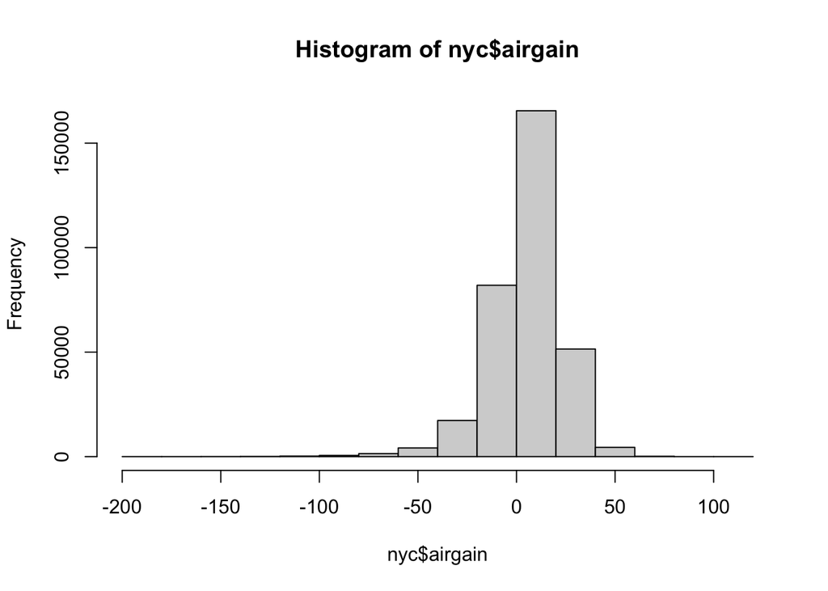

```r
hist(nyc$airgain)
```

### Do airlines actually gain any time when in air on average?

```r
average_airgain <- round(mean(nyc$airgain, na.rm=TRUE),2)
average_airgain
```

```
## [1] 5.66
```

**On average, airlines gain 5.66 minutes in air.**

### Average airgain for different airlines:

```r
avg_airgain_by_airline <- round(tapply(nyc$airgain,nyc$carrier,mean,na.rm=TRUE),2)
sort(avg_airgain_by_airline)
```

```
##    F9    FL    MQ    OO    US    YV    B6    EV    DL    WN    AA    UA    9E
## -1.72 -1.51 -0.33  0.66  1.62  3.34  3.51  4.04  7.58  8.01  8.20  8.46  9.06
##    VX    HA    AS
## 10.99 11.82 15.76
```

```r
best_airgain <- head(sort(names(avg_airgain_by_airline)))
worst_airgain <- tail(sort(names(avg_airgain_by_airline)))
```

Below is a barplot to depict the best and worst airlines for airgain:

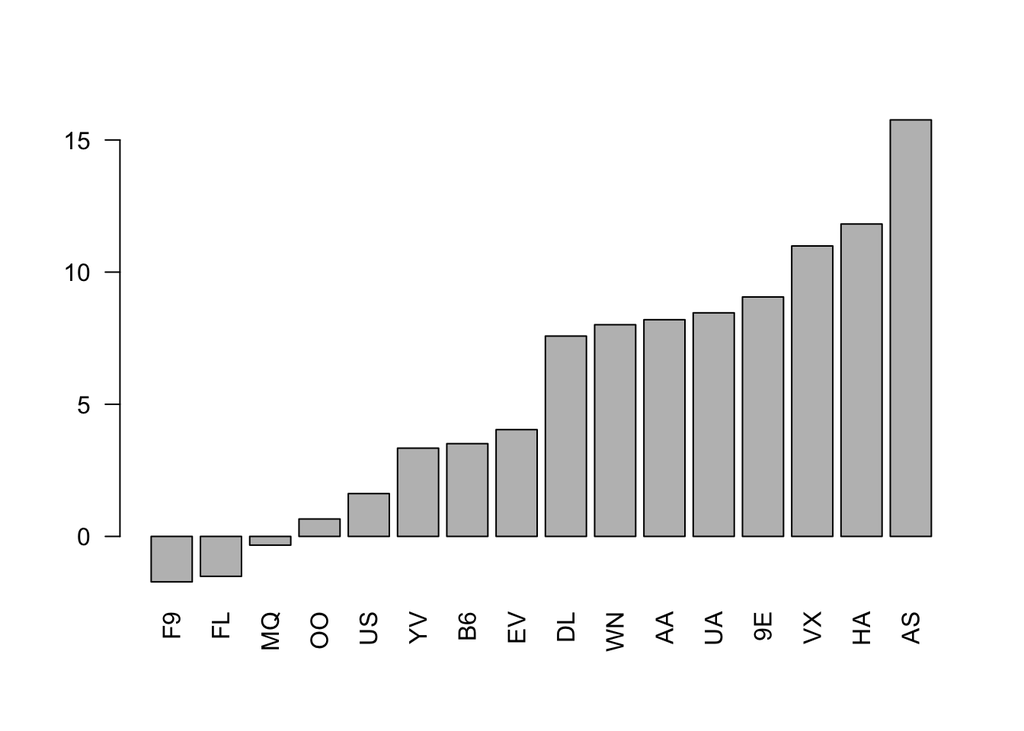

```r
barplot(sort(avg_airgain_by_airline, decreasing = FALSE),las=2)
```